# Practical ML Course Project

Enrique Figueroa

25/10/2021

### Background

Six people using accelerometers on their bodies are asked to perform barbell lifts in 5 different ways. It have been identified 5 different ways to do it, called Class A, B, C, D and E. Only the Class A is considered correct. Many measures have been taken and been registered at the indicated datasets. The task is to train a model that predict correctly the Class based on relevant columns of the datasets.

### Loading libraries and datasets

```r
rm(list=ls())

library(caret)
library(ggplot2);
library(dplyr)

training <- read.csv(file="pml-training.csv", header=T)
validation <- read.csv(file="pml-testing.csv", header=T)
```

### Preprocesing

Since the training dataset has redundant summary fields we reduced to those that can have an impact on the outcome. Also, ignore some useless columns.

```r
relevant_cols= c("accel_", "gyros_", "roll_", "pitch_","yaw_", "magnet_")
train_df = select(training, classe, starts_with(relevant_cols))
sort(colnames(train_df) )
```

```
##  [1] "accel_arm_x"       "accel_arm_y"       "accel_arm_z"
##  [4] "accel_belt_x"      "accel_belt_y"      "accel_belt_z"
##  [7] "accel_dumbbell_x"  "accel_dumbbell_y"  "accel_dumbbell_z"
## [10] "accel_forearm_x"   "accel_forearm_y"   "accel_forearm_z"
## [13] "classe"            "gyros_arm_x"       "gyros_arm_y"
## [16] "gyros_arm_z"       "gyros_belt_x"      "gyros_belt_y"
## [19] "gyros_belt_z"      "gyros_dumbbell_x"  "gyros_dumbbell_y"
## [22] "gyros_dumbbell_z"  "gyros_forearm_x"   "gyros_forearm_y"
## [25] "gyros_forearm_z"   "magnet_arm_x"      "magnet_arm_y"
## [28] "magnet_arm_z"      "magnet_belt_x"     "magnet_belt_y"
## [31] "magnet_belt_z"     "magnet_dumbbell_x" "magnet_dumbbell_y"
## [34] "magnet_dumbbell_z" "magnet_forearm_x"  "magnet_forearm_y"
## [37] "magnet_forearm_z"  "pitch_arm"         "pitch_belt"
## [40] "pitch_dumbbell"    "pitch_forearm"     "roll_arm"
## [43] "roll_belt"         "roll_dumbbell"     "roll_forearm"
## [46] "yaw_arm"           "yaw_belt"          "yaw_dumbbell"
## [49] "yaw_forearm"
```

The pie below shows that the majority of participants perform incorrectly the barbell lifts (Class B, C, D, E). Only 28.4% perform the lifts correctly.

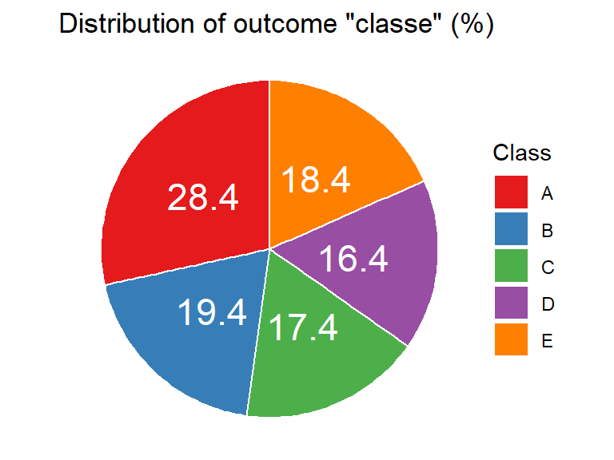

```r
table_pie =as.data.frame(table(train_df$classe))
colnames(table_pie) = c("Class", "Freq")
table_pie = table_pie %>% arrange(desc(Class)) %>%
  mutate(prop = Freq / sum(table_pie$Freq) * 100) %>%
  mutate(ypos = cumsum(prop) - 0.5*prop )

ggplot(table_pie, aes(x="", y=prop, fill=Class)) +
  geom_bar(stat="identity", width=1, color="white") +
  coord_polar("y", start=0) + theme_void() +
  geom_text(aes(y = ypos, label = round(prop,1)), color = "white", size=6) +
  scale_fill_brewer(palette="Set1") + ggtitle("Distribution of outcome \"classe\" (%)")
```

### Partioning the training dataset

Now that we reduced the dataset from 160 columns to only 49 columns, we divide the huge training dataset in two parts: one for training the models (60%) and the other one for testing their performance (40%).

```r
inTrain = createDataPartition(y=train_df$classe, p=0.6, list=FALSE)

train_df = train_df[inTrain, ];
test_df = train_df[-inTrain, ]
```

### Training models

First, we set up the cross validation parameter to 2-fold. This parameter will be used in the train function for each model.

```r
set.seed(7777)
control = trainControl(method="cv", number=2, verboseIter=F)
```

### Decision Trees

```r
mod_dt = train(classe ~ ., data=train_df, method="rpart", trControl = control)
```

### Random Forests

```r
mod_rf = train(classe~., data=train_df, method="rf", trControl = control)
```

### Generalized Boosted Regression Modeling

```r
mod_gbm = train(classe~., data=train_df, method="gbm", trControl = control, verbose = F)
```

### Suppor Vector Machine

```r
mod_svm = train(classe~., data=train_df, method="svmLinear", trControl = control, verbose = F)
```

### Linear Discriminant Analysis

```r
mod_lda = train(classe ~ ., data = train_df, method = "lda", trControl = control, verbose = F)
```

### Prediction

Once the models have been trained we predict the classes (A, B, C, D or E) on the test_df to calculate some metrics. Since the procedure is the same for the five models a function is defined previously for calculating the confusion matrix.

```r
pred_model = function(model, dataset){
  mod_predict = predict(model, dataset)
  conf_matrix = confusionMatrix(mod_predict, as.factor(dataset$classe))
  return(conf_matrix)
}
```

Then, we calculate each confusion matrix.

```r
cm_dt = pred_model(mod_dt, test_df)
cm_rf = pred_model(mod_rf, test_df)
cm_gbm = pred_model(mod_gbm, test_df)
cm_svm = pred_model(mod_svm, test_df)
cm_lda = pred_model(mod_lda, test_df)
```

### Results on testing dataset

Based upon the prior calculated confusion matrices, we build a table that shows the accuracy of each model.

```r
res = round( rbind(
  "Decision Trees" = cm_dt$overall["Accuracy"],
  "Random Forest" = cm_rf$overall["Accuracy"],
  "Generalized Boosting " = cm_gbm$overall["Accuracy"],
  "Support Vector Machine" = cm_svm$overall["Accuracy"],
  "Linear Discriminant Analysis" = cm_lda$overall["Accuracy"]
), 2)

knitr::kable(res, caption = "**Overall model accuracy**", format="simple")
```

**Overall model accuracy**

|  | Accuracy |
| --- | --- |
| Decision Trees | 0.37 |
| Random Forest | 1.00 |
| Generalized Boosting | 0.98 |
| Support Vector Machine | 0.77 |
| Linear Discriminant Analysis | 0.70 |

Since what we are mostly interesed in calculating the Class A and not the other classes that represent mistakes, a table with relevant metrics for that Class A is composed with a function that takes the trained model as an argument.

```r
table_row = function(model, modelName){
  result = rbind(
  "Bal Accuracy"= round(model$byClass[1,7],2),
  "Sensitivity"= round(model$byClass[1,1],2),
  "Specificity"= round(model$byClass[1,2],2),
  "Precision"= round(model$byClass[1,5],2),
  "Recall"= round(model$byClass[1,6],2))

  result = t(as.data.frame(result))
  rownames(result) = modelName

  return(result)
}

classA_result = rbind(
table_row(cm_dt, "Decision Trees"),
table_row(cm_rf, "Random Forest"),
table_row(cm_gbm, "Generalized Boosting"),
table_row(cm_svm, "Support Vector Machine"),
table_row(cm_lda, "Linear Discriminant Analysis") )

knitr::kable(classA_result, caption = "**Class A metrics**", format="simple")
```

**Class A metrics**

|  | Bal Accuracy | Sensitivity | Specificity | Precision | Recall |
| --- | --- | --- | --- | --- | --- |
| Decision Trees | 0.48 | 1.00 | 0.12 | 0.31 | 1.00 |
| Random Forest | 1.00 | 1.00 | 1.00 | 1.00 | 1.00 |
| Generalized Boosting | 0.99 | 0.99 | 0.99 | 0.98 | 0.99 |
| Support Vector Machine | 0.85 | 0.91 | 0.91 | 0.80 | 0.91 |
| Linear Discriminant Analysis | 0.80 | 0.83 | 0.90 | 0.77 | 0.83 |

### Prediction on validation dataset

```r
pred_val <- predict(mod_rf, validation)
print(pred_val)
```

```
##  [1] B A B A A E D B A A B C B A E E A B B B
## Levels: A B C D E
```

### Appendix

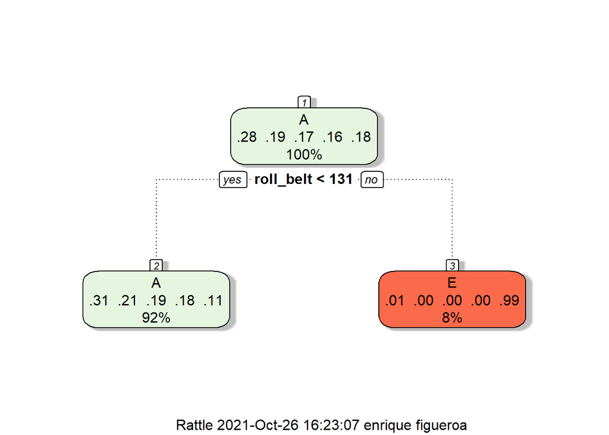

```r
library(rattle)
fancyRpartPlot(mod_dt$finalModel)
```